# HW3

Lowson Li, R08323023

# 1 Strategy

1. Try to find the package to simplify the calculation
2. Try to code by myself

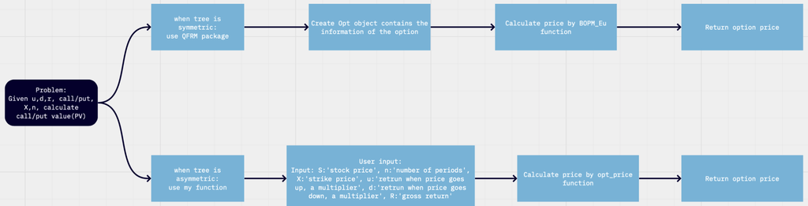

- For more details of the code and instructions, please visit my [Github](https://github.com/isthatlowsonli/Financial_Engineering)
- [Source code](https://github.com/isthatlowsonli/Financial_Engineering/blob/master/Script/HW3.Rmd)
- [Academic Portfolio](https://isthatlowsonli.github.io//Financial_Engineering/Script/practice.nb.html)

# 2 Load packages

```r
library(dplyr)
library(knitr)
library(QFRM)
library(kableExtra)
```

# 3 With QFRM package

**Pricing of Vanilla and Exotic Option Contracts** Option pricing (financial derivatives) techniques mainly following textbook ‘Options, Futures and Other Derivatives’, 9ed by John C.Hull, 2014. Prentice Hall. Implementations are via binomial tree option model (BOPM), Black-Scholes model, Monte Carlo simulations, etc. This package is a result of Quantitative Financial Risk Management course (STAT 449 and STAT 649) at Rice University, Houston, TX, USA, taught by Oleg Melnikov, statistics PhD student, as of Spring 2015.

```r
o <- Opt(Style = "European", Right = "Call", S0 = 160, ttm = 3, K = 150) # An OptPx object
(o <- BOPM_Eu(OptPx(o, r = 0.18232, NSteps = 3)))$PxBT # option price value
```

```
[1] 76.42035
```

This function only recombining **symmetric** binomial tree. In HW case, we need to construct asymmetric one.

Note: `Opt` arguments

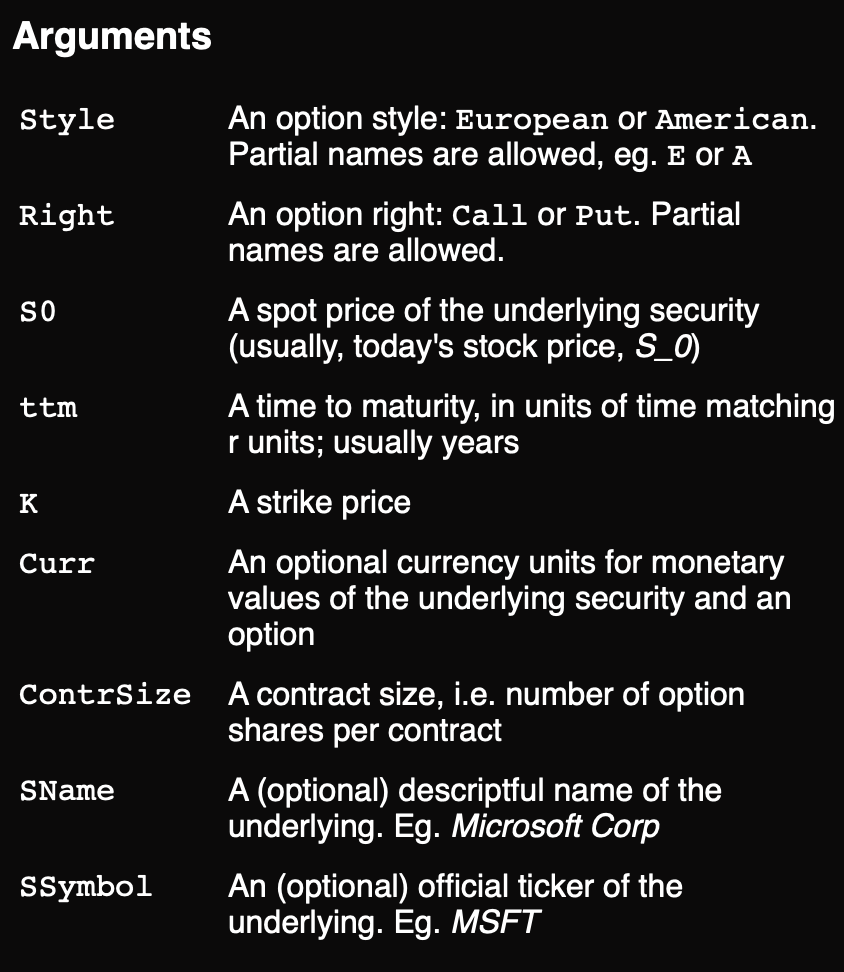

# 4 With asymmetric binomial tree

For pseudo probability (risk-neutral probability), we have

$$p \triangleq \frac{R-d}{u-d}$$
where R denotes to the **gross return**

```r
# define pseudo probability
p_prob <- function(R, u, d) {
  p <- (R - d) / (u - d)
  return(p)
}
```

```r
# calculate pseudo probability
p_prob(R = 1.2, u = 1.5, d = 0.5)
```

```
[1] 0.7
```

By the backward induction, we have **call** option price $\mathrm{C}$

$$\mathrm{C} = \frac{\sum_{j=0}^{n}\binom{n}{j}p^{n}(1-p)^{n-j}\times \max(0,S_{0}u^{n}d^{n-j}-X)}{R^{n}}$$
where $j = 0,...,n$

```r
# define function
# Input: S:'stock price', n:'number of periods', X:'strike price', u:'retrun when price goes up, a multiplier', d:'retrun when price goes down, a multiplier', R:'gross return'
opt_price <- function(S, n, X, u, d, R) {
  p <- (R - d) / (u - d) # calculate the pseudo probability
  tree <- c() # create empty vector
  for (i in 0:n) {
    tree[i] <- choose(n, i) * (p^i) * (1 - p)^(n - i) * max(0, S * (u^i) * d^(n - i) - X) # store payoff in the vector
  }
  return(sum(tree) / (R^n)) # calculate the option price and return
}
```

Notice that the gross resturn is equivelent to

$$R \triangleq e^{\hat{r}}$$

where $\hat{r}$ is the continuously compounded riskless rate per period

Thus, the call price is

```r
opt_price(S = 160,n = 3,X = 150,u = 1.5,d = 0.5,R = 1.2)
```

```
[1] 85.06944
```

Also, we have **put** option price $\mathrm{P}$ with price formula
$$\mathrm{P} = \frac{\sum_{j=0}^{n}\binom{n}{j}p^{n}(1-p)^{n-j}\times \max(0,X-S_{0}u^{n}d^{n-j})}{R^{n}}$$

For call option price:

```r
opt_price(S = 160, n = 3, X = 150, u = 1.5, d = 0.5, R = 1.2, type = "call")
```

[output not shown]

```
[1] 85.06944
```

For put option price:

```r
opt_price(S = 160, n = 3, X = 150, u = 1.5, d = 0.5, R = 1.2, type = "put")
```

[output not shown]

```
[1] 11.875
```

Validate the put price with **put call parity**

$$\begin{equation}
\begin{aligned}
C+Xe^{-rT} &= P+S \\
where \ \ C &= call \ premium \\
Xe^{-rT} &= present \ value \ of \ the \ strike \\
P &= put \ premium \\
S &= the \ current \ price \ of \ the \ underline \\
\end{aligned}
\end{equation}$$

```r
85.06944 + 150/(1.2^3) - 160
```

```
[1] 11.875
```

# 5 Reference

[BOPM - RDocumentation](https://www.rdocumentation.org/packages/QFRM/versions/1.0.1/topics/BOPM)

[Binomial Options Pricing Model with R](https://github.com/uigc/bopm)